# Informe

Fredy Velasquez , Pablo Escobar , Angel Higueros

14/4/2023

## Hoja de trabajo 6: Modelos de regresion logistica

```r
library(ModelMetrics)
library(ggplot2)
library(caret)
library(dummies)
library(GGally)

data<-read.csv('train.csv')
```

#### 1.Cree una variable dicotómica por cada una de las categorías de la variable respuesta categórica que creó en hojas anteriores. Debería tener 3 variables dicotómicas (valores 0 y 1) una que diga si la vivienda es cara o no, media o no, económica o no.

```r
data[is.na(data)] <- 0
#Calculo de percentiles
percentil <- quantile(data$SalePrice)
#Percentiles
estado<-c('Estado')
data$Estado<-estado
#Economica=0
#Intermedia=1
#Cara=2
data <- within(data, Estado[SalePrice<=129975] <- 0)
data$Estado[(data$SalePrice>129975 & data$SalePrice<=163000)] <- 1
data$Estado[data$SalePrice>163000] <- 2
#Modelo de Regresion logistica
porcentaje<-0.7
datos<-data
#Experimento reproducible
set.seed(123)
#Variables dicotomicas
datos<-cbind(datos,dummy(data$Estado,verbose = T))
```

```
##   D:/Users/MAQUITO/Desktop/UVG/UVG S7/Mineria de datos/HDT6/Informe.Rmd : 3 dummy varibles created
```

```r
names (datos)[85] = "Cara"
names (datos)[84] = "Intermedia"
names (datos)[83] = "Economica"

head(datos,n=3)
```

```
##   Id MSSubClass MSZoning LotFrontage LotArea Street Alley LotShape LandContour
## 1  1         60       RL          65    8450   Pave     0      Reg         Lvl
## 2  2         20       RL          80    9600   Pave     0      Reg         Lvl
## 3  3         60       RL          68   11250   Pave     0      IR1         Lvl
##   Utilities LotConfig LandSlope Neighborhood Condition1 Condition2 BldgType
## 1    AllPub    Inside       Gtl      CollgCr       Norm       Norm     1Fam
## 2    AllPub       FR2       Gtl      Veenker      Feedr       Norm     1Fam
## 3    AllPub    Inside       Gtl      CollgCr       Norm       Norm     1Fam
##   HouseStyle OverallQual OverallCond YearBuilt YearRemodAdd RoofStyle RoofMatl
## 1     2Story           7           5      2003         2003     Gable  CompShg
## 2     1Story           6           8      1976         1976     Gable  CompShg
## 3     2Story           7           5      2001         2002     Gable  CompShg
##   Exterior1st Exterior2nd MasVnrType MasVnrArea ExterQual ExterCond Foundation
## 1     VinylSd     VinylSd    BrkFace        196        Gd        TA      PConc
## 2     MetalSd     MetalSd       None          0        TA        TA     CBlock
```

[output cut: 37 more lines]

#### 2.Use los mismos conjuntos de entrenamiento y prueba que utilizó en las hojas anteriores.

```r
corte <- sample(nrow(datos),nrow(datos)*porcentaje)
train<-datos[corte,]
test<-datos[-corte,]
```

#### 3.Primer modelo

```r
#Queremos saber si una casa es cara o no

modelo<-glm(Cara~., data = train[,c('SalePrice','GrLivArea','Cara','LotFrontage','LotArea','BsmtQual','PoolArea')],family = binomial(), maxit=100)
modelo
```

```
##
## Call:  glm(formula = Cara ~ ., family = binomial(), data = train[, c("SalePrice",
##     "GrLivArea", "Cara", "LotFrontage", "LotArea", "BsmtQual",
##     "PoolArea")], maxit = 100)
##
## Coefficients:
## (Intercept)    SalePrice    GrLivArea  LotFrontage      LotArea   BsmtQualEx
##  -8.218e+15    3.834e+10    1.393e+11    7.514e+11    2.381e+09    1.748e+15
##  BsmtQualFa   BsmtQualGd   BsmtQualTA     PoolArea
##   1.091e+13    1.748e+15    1.635e+15   -4.993e+12
##
## Degrees of Freedom: 1020 Total (i.e. Null);  1011 Residual
## Null Deviance:       1415
## Residual Deviance: 72.09     AIC: 92.09
```

En este modelo lo que queremos saber es si la casa es cara o no, esto mediante las variables **‘SalePrice’,‘GrLivArea’,‘Cara’,‘LotFrontage’,‘LotArea’,‘BsmtQual’,‘PoolArea’**.

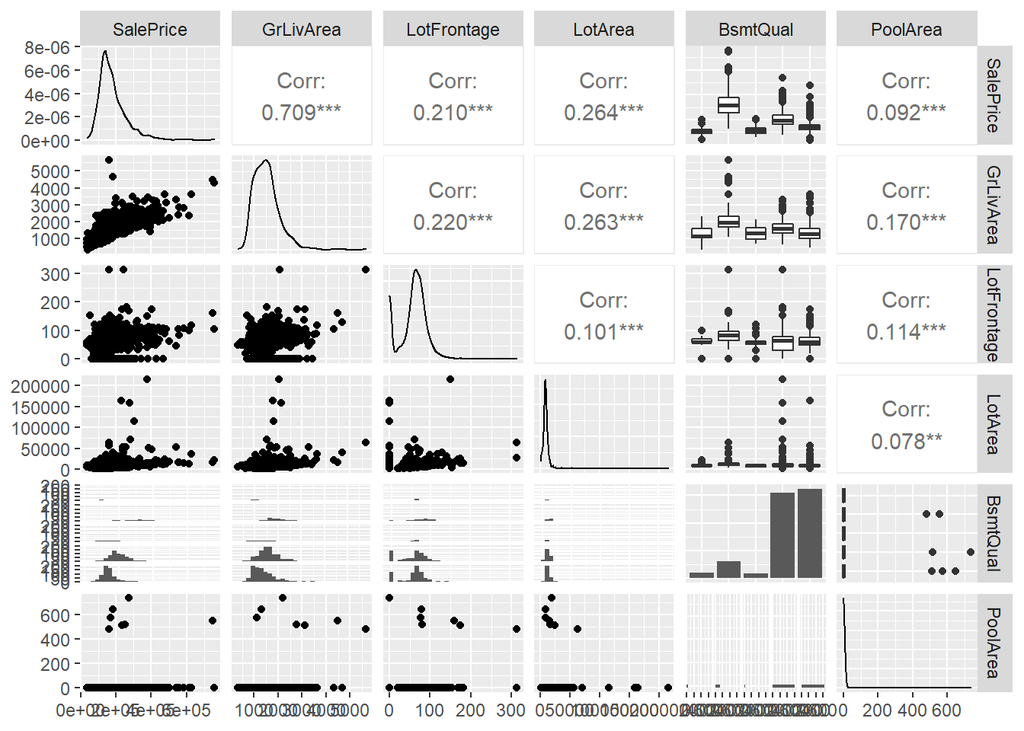

```r
#Correlacion de las variables

ggpairs(datos[,c('SalePrice','GrLivArea','LotFrontage','LotArea','BsmtQual','PoolArea')])
```

```r
##Modelo con todas las variables
pred<-predict(modelo,newdata = test[,c('SalePrice','GrLivArea','LotFrontage','LotArea','BsmtQual','PoolArea')], type = "response")
prediccion<-ifelse(pred>=0.5,1,0)
confusionMatrix(as.factor(test$Cara),as.factor(prediccion))
```

```
## Confusion Matrix and Statistics
##
##           Reference
## Prediction   0   1
##          0 213   1
##          1   7 218
##
##                Accuracy : 0.9818
##                  95% CI : (0.9644, 0.9921)
##     No Information Rate : 0.5011
##     P-Value [Acc > NIR] : <2e-16
##
##                   Kappa : 0.9636
##
##  Mcnemar's Test P-Value : 0.0771
##
##             Sensitivity : 0.9682
##             Specificity : 0.9954
##          Pos Pred Value : 0.9953
##          Neg Pred Value : 0.9689
##              Prevalence : 0.5011
##          Detection Rate : 0.4852
##    Detection Prevalence : 0.4875
##       Balanced Accuracy : 0.9818
##
##        'Positive' Class : 0
##
```

Como se observa en la matriz de confusion este modelo tuvo una precision de **98.18%**, donde obtuvo 8 casas de error, indicando que fue una buena prediccion, no obstante, mas adelante veremos si tiene o no overfitting.

```r
#Modelo para verificar overfitting

trainPredict<-predict(modelo,newdata = train[,c('SalePrice','GrLivArea','LotFrontage','LotArea','BsmtQual','PoolArea')], type = "response")
trainPred<- ifelse(trainPredict>0.5,1,0)
confusionMatrix(as.factor(train$Cara),as.factor(trainPred))
```

```
## Confusion Matrix and Statistics
##
##           Reference
## Prediction   0   1
##          0 517   1
##          1   0 503
##
##                Accuracy : 0.999
##                  95% CI : (0.9946, 1)
##     No Information Rate : 0.5064
##     P-Value [Acc > NIR] : <2e-16
##
##                   Kappa : 0.998
##
##  Mcnemar's Test P-Value : 1
##
##             Sensitivity : 1.0000
##             Specificity : 0.9980
##          Pos Pred Value : 0.9981
##          Neg Pred Value : 1.0000
##              Prevalence : 0.5064
##          Detection Rate : 0.5064
##    Detection Prevalence : 0.5073
##       Balanced Accuracy : 0.9990
##
##        'Positive' Class : 0
##
```

Se crea un modelo para pode comparar la prediccion.

```r
#Calculo de rmse para ver si tenemos overfitting, mientras mas cercano a 0 mayor overffiting.

rmse(test$Cara,prediccion)
```

```
## [1] 0.1349935
```

Tal como se observa se obtuvo un RMSE alejado de 0, esto indica que este modelo no tuvo overfitting.

```r
train_numerico<-train[,c('SalePrice','GrLivArea','Cara','LotFrontage','LotArea','BsmtQual','PoolArea')]
modeloCaret<-train(Cara~.,trControl=trainControl('none'),
                   train_numerico,
                   method='glm',family='binomial')

varImp(modeloCaret)
```

```
## glm variable importance
##
##              Overall
## SalePrice   100.0000
## BsmtQualTA   20.1691
## BsmtQualGd   19.5731
## BsmtQualEx   19.3422
## GrLivArea     8.7623
## BsmtQualFa    8.7040
## PoolArea      8.4702
## LotArea       0.7278
## LotFrontage   0.0000
```

#### 7.Segundo modelo

```r
#Queremos saber si una casa es cara o no

modelo<-glm(Intermedia~., data = train[,c('GarageArea','GarageCars','Intermedia','MoSold','GarageYrBlt','MasVnrArea','MiscVal')],family = binomial(), maxit=100)
modelo
```

```
##
## Call:  glm(formula = Intermedia ~ ., family = binomial(), data = train[,
##     c("GarageArea", "GarageCars", "Intermedia", "MoSold", "GarageYrBlt",
##         "MasVnrArea", "MiscVal")], maxit = 100)
##
## Coefficients:
## (Intercept)   GarageArea   GarageCars       MoSold  GarageYrBlt   MasVnrArea
##  -1.374e+00    2.342e-05   -9.719e-01   -2.711e-02    1.149e-03   -5.651e-04
##     MiscVal
##   1.661e-04
##
## Degrees of Freedom: 1020 Total (i.e. Null);  1014 Residual
## Null Deviance:       1163
## Residual Deviance: 1093  AIC: 1107
```

Con este modelo se busca determinar si una casa es intermedia o no, utilizando las variables **‘GarageArea’,‘GarageCars’,‘Intermedia’,‘MoSold’,‘GarageYrBlt’,‘MasVnrArea’,‘MiscVal’**.

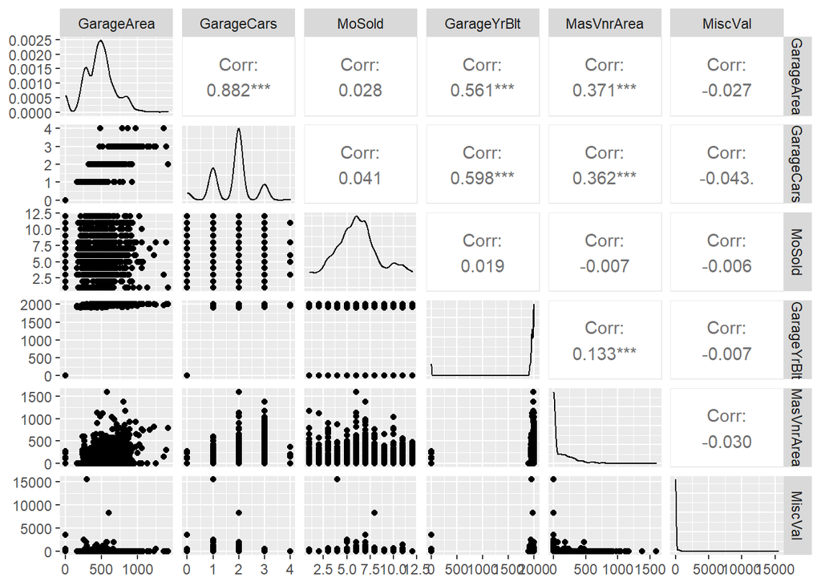

```r
#Correlacion de las variables

ggpairs(datos[,c('GarageArea','GarageCars','MoSold','GarageYrBlt','MasVnrArea','MiscVal')])
```

En el gráfico anterior se observa que la mayoria de las variables no tienen buena correlación, sobre todo la variable **MiscVal**, sin embargo, las variables **GarageCars** y **GarageYrBlt** sí tienen buena correlación. Entonces se puede concluir que esta combinación de variables no es la más adecuada para el modelo, pero se decidió dejar por fines didácticos.

```r
##Modelo con todas las variables
pred<-predict(modelo,newdata = test[,c('GarageArea','GarageCars','MoSold','GarageYrBlt','MasVnrArea','MiscVal')], type = "response")
prediccion<-ifelse(pred>=0.5,1,0)
confusionMatrix(as.factor(test$Intermedia),as.factor(prediccion))
```

```
## Confusion Matrix and Statistics
##
##           Reference
## Prediction   0   1
##          0 332   2
##          1 105   0
##
##                Accuracy : 0.7563
##                  95% CI : (0.7133, 0.7957)
##     No Information Rate : 0.9954
##     P-Value [Acc > NIR] : 1
##
##                   Kappa : -0.009
##
##  Mcnemar's Test P-Value : <2e-16
##
##             Sensitivity : 0.7597
##             Specificity : 0.0000
##          Pos Pred Value : 0.9940
##          Neg Pred Value : 0.0000
##              Prevalence : 0.9954
##          Detection Rate : 0.7563
##    Detection Prevalence : 0.7608
##       Balanced Accuracy : 0.3799
##
##        'Positive' Class : 0
##
```

Este modelo tuvo una precision de **75.63%**, tal y como se observa en la matriz de confusión mostrada anteriormente. Se obtuvieron 107 casas de error, indicando que no fue la mejor prediccion, pero si es significativa basándonos en la precisión. A continuación se observará si tiene overfitting o no.

```r
#Modelo para verificar overfitting

trainPredict<-predict(modelo,newdata = train[,c('GarageArea','GarageCars','MoSold','GarageYrBlt','MasVnrArea','MiscVal')], type = "response")
trainPred<- ifelse(trainPredict>0.5,1,0)
confusionMatrix(as.factor(train$Intermedia),as.factor(trainPred))
```

```
## Confusion Matrix and Statistics
##
##           Reference
## Prediction   0   1
##          0 758   1
##          1 261   1
##
##                Accuracy : 0.7434
##                  95% CI : (0.7154, 0.7699)
##     No Information Rate : 0.998
##     P-Value [Acc > NIR] : 1
##
##                   Kappa : 0.0037
##
##  Mcnemar's Test P-Value : <2e-16
##
##             Sensitivity : 0.743867
##             Specificity : 0.500000
##          Pos Pred Value : 0.998682
##          Neg Pred Value : 0.003817
##              Prevalence : 0.998041
##          Detection Rate : 0.742409
##    Detection Prevalence : 0.743389
##       Balanced Accuracy : 0.621933
##
##        'Positive' Class : 0
##
```

Modelo para comparar con la predicción.

```r
#Calculo de rmse para ver si tenemos overfitting, mientras mas cercano a 0 mayor overffiting.

rmse(test$Intermedia,prediccion)
```

```
## [1] 0.493696
```

Se observa que se obtuvo un RMSE alejado de 0, siendo **0.493696**, indicando que este modelo no tiene overfitting.

```r
train_numerico<-train[,c('GarageArea','GarageCars','Intermedia','MoSold','GarageYrBlt','MasVnrArea','MiscVal')]

modeloIntet<-train(Intermedia~.,trControl=trainControl('none'),
                   train_numerico,
                   method='glm',family='binomial')

varImp(modeloIntet)
```

```
## glm variable importance
##
##             Overall
## GarageYrBlt  100.00
## GarageCars    84.34
## MasVnrArea    19.60
## MoSold        17.80
## MiscVal       15.85
## GarageArea     0.00
```

#### 7.Tercer modelo

```r
#Queremos saber si una casa es cara o no

modelo<-glm(Economica~., data = train[,c('TotalBsmtSF','MasVnrArea','Economica','YearRemodAdd','GrLivArea','WoodDeckSF')],family = binomial(), maxit=100)
modelo
```

```
##
## Call:  glm(formula = Economica ~ ., family = binomial(), data = train[,
##     c("TotalBsmtSF", "MasVnrArea", "Economica", "YearRemodAdd",
##         "GrLivArea", "WoodDeckSF")], maxit = 100)
##
## Coefficients:
##  (Intercept)   TotalBsmtSF    MasVnrArea  YearRemodAdd     GrLivArea
##    97.887543     -0.003212     -0.003330     -0.046405     -0.002806
##   WoodDeckSF
##    -0.003851
##
## Degrees of Freedom: 1020 Total (i.e. Null);  1015 Residual
## Null Deviance:       1150
## Residual Deviance: 627.2     AIC: 639.2
```

Con este modelo se busca determinar si una casa es Economica o no, utilizando las variables **‘TotalBsmtSF’,‘MasVnrArea’,‘Economica’,‘YearRemodAdd’,‘GrLivArea’,‘WoodDeckSF’**.

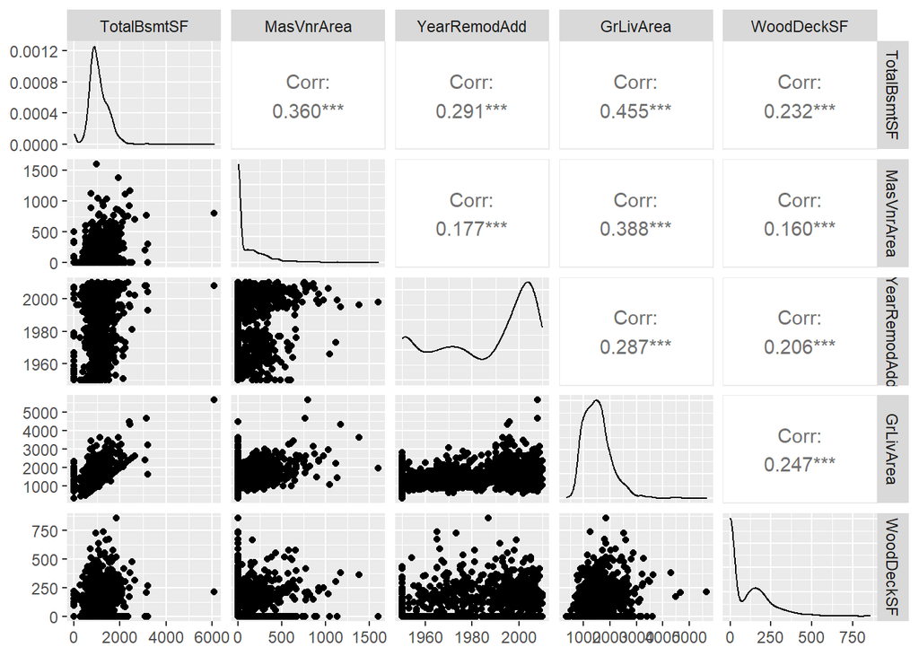

```r
#Correlacion de las variables

ggpairs(datos[,c('TotalBsmtSF','MasVnrArea','YearRemodAdd','GrLivArea','WoodDeckSF')])
```

En el gráfico anterior se observa que la mayoria de las variables no tienen buena correlación, sobre todo la variable **WoodDeckSF**, sin embargo, las variables **MasVnrArea** y **GrLivArea** tienen una correlación medianamente correcta o por lo menos usable. Entonces se puede concluir que esta combinación de variables no es la más adecuada para el modelo, pero se quiso llegar a determinar una relacion entre areas, año de remodelacion y espacio de madera.

```r
##Modelo con todas las variables
pred<-predict(modelo,newdata = test[,c('TotalBsmtSF','MasVnrArea','YearRemodAdd','GrLivArea','WoodDeckSF')], type = "response")
prediccion<-ifelse(pred>=0.5,1,0)
confusionMatrix(as.factor(test$Economica),as.factor(prediccion))
```

```
## Confusion Matrix and Statistics
##
##           Reference
## Prediction   0   1
##          0 308  22
##          1  34  75
##
##                Accuracy : 0.8724
##                  95% CI : (0.8376, 0.9022)
##     No Information Rate : 0.779
##     P-Value [Acc > NIR] : 3.871e-07
##
##                   Kappa : 0.6452
##
##  Mcnemar's Test P-Value : 0.1416
##
##             Sensitivity : 0.9006
##             Specificity : 0.7732
##          Pos Pred Value : 0.9333
##          Neg Pred Value : 0.6881
##              Prevalence : 0.7790
##          Detection Rate : 0.7016
##    Detection Prevalence : 0.7517
##       Balanced Accuracy : 0.8369
##
##        'Positive' Class : 0
##
```

Este modelo tuvo una precision de **87.24%**, o bien de **0.8724** tal y como se observa en la matriz de confusión mostrada anteriormente, indicando que fue una prediccion medianamente buena. A continuación se observará si tiene overfitting o no.

```r
#Modelo para verificar overfitting

trainPredict<-predict(modelo,newdata = train[,c('TotalBsmtSF','MasVnrArea','YearRemodAdd','GrLivArea','WoodDeckSF')], type = "response")
trainPred<- ifelse(trainPredict>0.5,1,0)
confusionMatrix(as.factor(train$Economica),as.factor(trainPred))
```

```
## Confusion Matrix and Statistics
##
##           Reference
## Prediction   0   1
##          0 712  53
##          1  82 174
##
##                Accuracy : 0.8678
##                  95% CI : (0.8454, 0.888)
##     No Information Rate : 0.7777
##     P-Value [Acc > NIR] : 1.496e-13
##
##                   Kappa : 0.6343
##
##  Mcnemar's Test P-Value : 0.01596
##
##             Sensitivity : 0.8967
##             Specificity : 0.7665
##          Pos Pred Value : 0.9307
##          Neg Pred Value : 0.6797
##              Prevalence : 0.7777
##          Detection Rate : 0.6974
##    Detection Prevalence : 0.7493
##       Balanced Accuracy : 0.8316
##
##        'Positive' Class : 0
##
```

Modelo para comparar con la predicción.

```r
#Calculo de rmse para ver si tenemos overfitting, mientras mas cercano a 0 mayor overffiting.

rmse(test$Economica,prediccion)
```

```
## [1] 0.3571591
```

Se observa que se obtuvo un RMSE alejado de 0, siendo **0.3571591**, indicando que este modelo no tiene overfitting.

```r
train_numerico<-train[,c('TotalBsmtSF','MasVnrArea', 'Economica','YearRemodAdd','GrLivArea','WoodDeckSF')]

modeloCaret<-train(Economica~.,trControl=trainControl('none'),
                   train_numerico,
                   method='glm',family='binomial')

varImp(modeloCaret)
```

```
## glm variable importance
##
##              Overall
## YearRemodAdd  100.00
## GrLivArea      96.58
## TotalBsmtSF    78.68
## WoodDeckSF      9.05
## MasVnrArea      0.00
```

#### 9

Como se puede observar, el modelo que mejor tuvo rendimiento fue el primero, desde que tiene una buena correlacion en sus variables hasta que tiene un porcentaje de efectividad mucho mayor.

Posiblemente para el caso de los modelos 2 y 3, se puedan llegar a mejorar, esto mediante la seleccion de otras varaibles que tengan una mayor correlacion, por ejemplo que tengan algun tipo de relacion entre ellas, por ejemplo si se puediera llegar a tener variables que manejan solo el tipo de material que se usa, los costos de la casa especificados en diferentes variables, entonces podemos decir que realmente estos modelos pueden mejorarse.